# Final Project

Author

Xiaorui Shi & Ruiyang Zhang

## Libraries

```r
library(tidyverse)
library(readr)
library(broom)
library(here)
library(tidymodels)
library(srvyr)
library(themis)
library(tictoc)
library(vip)
library(tune)
library(MatchIt)
library(cobalt)
```

## Background

In recent years, the issue of rising household energy bills has garnered increasing attention in the United States. As [Pioneer Energy](https://pioneerec.com/4-key-factors-that-affect-energy-bills/) outlines, several critical factors contribute to household energy expenses: **home size**, **insulation quality**, **appliance efficiency**, and **weather/climate**. Likewise, [ElectricChoice.com](https://www.electricchoice.com/blog/8-key-factors-impact-electricity-prices/) identifies broader drivers such as **fuel prices**, **power plant operations**, **transmission infrastructure**, and **government regulations**.

These insights help explain why household energy costs vary widely across income levels, housing characteristics, and geographic regions. This variation is also evident in our dataset from the Residential Energy Consumption Survey (RECS), which we use in this project.

## Our Project

Our research aims to analyze energy cost disparities and evaluate the potential impact of **solar panel adoption** as well as a proposed **energy credit policy** targeting vulnerable households. The project includes:

1. **Descriptive analysis** of household energy cost patterns by income, house size, and solar ownership.
2. **Machine learning models** (Lasso, Random Forest, and XGBoost) to predict household annual energy cost.
3. **Nonparametric causal inference methods** (nearest-neighbor matching and permutation testing) to estimate the effect of solar panels on energy cost.
4. **A microsimulation policy tool** to calculate and simulate targeted energy credit allocations.

## Data

```r
raw_recs <- readr::read_csv(here("data", "RECS", "recs2020_public_v7.csv")) %>%
  janitor::clean_names()
```

This dataset contains household-level energy characteristics on the housing unit, usage patterns, household demographics, and energy bills in 2020. An observation can be uniquely identified by DOEID. This dataset includes both character and numeric columns.  
Source: [2020 Residential Energy Consumption Survey (RECS)](https://www.eia.gov/consumption/residential/data/2020/)

# Preliminary Data Cleaning

## Variable selection

```r
recs<- raw_recs %>%
  select(!starts_with("z")) %>% # drop imputation indicator
  rename(final_nweight = nweight,
         cost = totaldol,
         evhome = evchrghome,
         energyassist = energyasst,
         finishbase = basefin,
         outbulb = lgtoutany,
         lightmore8=lgtinmore8,
         led = lgtinled) %>%
  select(!starts_with("btu")) %>%
  select(!starts_with("nweight")) %>%
  select(!starts_with("dol")) %>%
  select(!ends_with("btu")) %>%
  select(!starts_with("totalbtu")) %>%
  select(!starts_with("kwh")) %>%
  select(!starts_with("gallon")) %>%
  select(!starts_with("cufeetng")) %>%
  select(!starts_with("period")) %>%
  select(!starts_with("totaldol")) %>%
  select(-c(regionc, state_fips, state_postal, iecc_climate_code, usehumid, useel, elother,elwater,elwarm,elfood,elcool,dvd,vcr,dbt99,dbt1,crawl,cooktopindt,combodvr,coldma,cellphone,cellar,cablesat,blender,atticfan,atticfin,appother,woodtype,tothsqft,totcsqft,tvonwe2,tvonwe3,tvonwd2,tvonwd3,tvsize2,tvsize3,tvtype2,tvtype3,ugoth,useequipaux,usecoffee,topfront,studio,sqftrange,smartspk,sizrfri2,sepdvr,poolpump,playsta,outlet,oven,ovenfuel,rangefuel,rangeindt,range,othrooms,origwin,nummeal,numtablet,numsmphone,numlaptop,nhafbath,monpool,lpother,locrfri2,intstream,ice,usehumid,numporthum,h2omain,h2oapt,gargheat,gargcool,foother,uprtfrzr,tvaudiosys,freezer,cooktopfuel,cooktop,agerfri2, usecfan, humidtype, dehumtype, usedehum,numportdehum, dwcycle, dryrfuel, heatapt, cwasher,heathome, dntheat, aircond,coolapt,stories)) %>%
  select(!starts_with("ev")) %>%
  select(!starts_with("energyasst")) %>%
  select(!starts_with("base")) %>%
  select(!starts_with("attc")) %>%
  select(!starts_with("acequip")) %>%
  select(!starts_with("tvuse")) %>%
  select(!starts_with("tl")) %>%
  select(!starts_with("ss")) %>%
  select(!starts_with("sqftin")) %>%
  select(!starts_with("outgrill")) %>%
  select(!starts_with("fuel")) %>%
  select(!starts_with("more")) %>%
  select(!starts_with("lgtout")) %>%
  select(!starts_with("lgtin")) %>%
  select(!starts_with("intype")) %>%
  select(!starts_with("equipaux")) %>%
  select(!starts_with("typerfr")) %>%
  select(!ends_with("pay"))
```

## Clean missing values

```r
# turn <0 to NA
recs <- recs %>%
  mutate(across(c(typetherm, tvtype1, tvsize1, starts_with("temp"), solar, sizrfri1, sizfreez, sizeofgarage, rooftype, highceil, equipm, washtemp),~ifelse(.<0, NA, .)))

# turn <0 to 0
recs <- recs %>%
  mutate(across(c(whypowerout, wheatbkt, tvonwe1, tvonwd1, telldays, swimpool, rovenuse, rcookuse, prkgplc1, payhelp, ovenuse, starts_with("num"), starts_with("no"), montub, intdataacc, housefan, heatcntl, geohp, dwashuse, dryruse, coolcntl, cooktopuse, concrete, finishbase, attic, amtmicro, washload),~ifelse(.<0, 0, .)))

# turn <0 to other values
recs <- recs %>%
  mutate(smartmeter = ifelse(smartmeter<0, 2, smartmeter),
         across(c(equipage, starts_with("age")),~ifelse(.<0, 1,.)))

# turn NA to 0
recs <- recs %>%
  mutate(medicaldev = ifelse(is.na(medicaldev), 0,medicaldev))
```

# Microsimulation

With a higher annual household energy costs and the inequity among household characteristics, we come up with a new policy initiative aiming to reduce the energy costs of households of low income and high energy costs by providing energy credits. The bullet points are:  
1. Energy credits are only eligible for households with an annual income lower than $25,000 and a energy cost per capita higher than $1,293.  
2. Household can receive a credit of $200 or $120 based on when their house was built.  
3. Each elderly person can receive a credit of $600 per year.  
4. If the household has a medical device in use, the household can receive a credit of $200 per year.  
5. Every one level increase of household income will deduct the credit by $2,500*0.05 = $125.

## Build a calculator for the new policy

```r
#' Calculate energy credit
#'
#' @param cost Annual energy cost
#' @param member Number of household members
#' @param income Household income level
#' @param year Year range the house built
#' @param elderly Number of adults older than 65 in household
#' @param medical Whether uses medical devices at home
#'
#' @returns Annual energy credit
#'
ec_calculator <- function(cost, member,income, year, elderly, medical) {
  avg = cost/member
  modified_income <- pmax(income - 1, 0)
  if (income<8 & avg >=1293) {
    if(year %in% c(1,2,6,7)){
      credit <- pmax(200 + elderly * 600 + medical * 200 - 0.05*2500*modified_income,0)
    }else if(year %in% c(3,4,5)){
      credit <- pmax(120 + elderly * 600 + medical * 200 - 0.05*2500*modified_income,0)
    }else{
      credit<-pmax(elderly * 600 + medical * 200 - 0.05*2500*modified_income,0)
    }
  } else {
    credit <- 0
  }

  return(credit)
}
```

## Apply the calculator to the dataset

```r
data_for_calculation <- recs %>%
  select(cost, nhsldmem, moneypy, yearmaderange, numadult2, medicaldev) %>%
  rename(member=nhsldmem,
         income=moneypy,
         year=yearmaderange,
         elderly=numadult2,
         medical = medicaldev)

energy_credit <- data_for_calculation %>%
  mutate(
    credit = pmap_dbl(
      data_for_calculation,
      .f = ec_calculator
    )
  )
```

## Check the policy result

```r
micro_recs <- left_join(energy_credit,recs,by=c("cost"="cost","member"="nhsldmem", "income"="moneypy","year"="yearmaderange","elderly"="numadult2","medical"="medicaldev")) %>%
  mutate(avg_cost = cost/member,
         avg_cost_decile = ntile(avg_cost, n = 10)) %>%
  as_survey_design(weights = final_nweight)

micro_recs %>%
  group_by(avg_cost_decile, income) %>%
  summarise(credit = mean(credit)) %>%
  pivot_wider(names_from = income, values_from = credit)
```

```
# A tibble: 10 × 17
# Groups:   avg_cost_decile [10]
   avg_cost_decile   `1`   `2`   `3`   `4`   `5`   `6`   `7`   `8`   `9`  `10`
             <int> <dbl> <dbl> <dbl> <dbl> <dbl> <dbl> <dbl> <dbl> <dbl> <dbl>
 1               1   0      0    0     0     0     0     0       0     0     0
 2               2   0      0    0     0     0     0     0       0     0     0
 3               3   0      0    0     0     0     0     0       0     0     0
 4               4   0      0    0     0     0     0     0       0     0     0
 5               5   0      0    0     0     0     0     0       0     0     0
 6               6   0      0    0     0     0     0     0       0     0     0
 7               7   0      0    0     0     0     0     0       0     0     0
 8               8  89.4    0   77.7  49.6  31.9  24.3  10.7     0     0     0
 9               9 312.   232  247.  258.  214.  131.   97.6     0     0     0
10              10 497.   393. 264.  245.  164.  129.   52.8     0     0     0
# ℹ 6 more variables: `11` <dbl>, `12` <dbl>, `13` <dbl>, `14` <dbl>,
#   `15` <dbl>, `16` <dbl>
```

## Check the policy outcome

```r
# add labels for better visualization
income_labels <- c(
  "Less than $5,000",
  "$5,000 - $7,499",
  "$7,500 - $9,999",
  "$10,000 - $12,499",
  "$12,500 - $14,999",
  "$15,000 - $19,999",
  "$20,000 - $24,999",
  "$25,000 - $29,999",
  "$30,000 - $34,999",
  "$35,000 - $39,999",
  "$40,000 - $49,999",
  "$50,000 - $59,999",
  "$60,000 - $74,999",
  "$75,000 - $99,999",
  "$100,000 - $149,999",
  "$150,000 or more"
)

micro_recs <- left_join(energy_credit,recs,by=c("cost"="cost","member"="nhsldmem", "income"="moneypy","year"="yearmaderange","elderly"="numadult2","medical"="medicaldev")) %>%
  mutate(avg_cost = cost/member,
         avg_cost_decile = ntile(avg_cost, n = 10),
         income = as.factor(income),
         income = factor(income, levels = 1:16, labels = income_labels)) %>%
  as_survey_design(weights = final_nweight)

# average credits by avg cost decile and income
micro_recs %>%
  group_by(avg_cost_decile, income) %>%
  summarise(credit = survey_mean(credit)) %>%
  select(-credit_se) %>%
  pivot_wider(names_from = income, values_from = credit)
```

```
# A tibble: 10 × 17
# Groups:   avg_cost_decile [10]
   avg_cost_decile `Less than $5,000` `$5,000 - $7,499` `$7,500 - $9,999`
             <int>              <dbl>             <dbl>             <dbl>
 1               1                 0                 0                0
 2               2                 0                 0                0
 3               3                 0                 0                0
 4               4                 0                 0                0
 5               5                 0                 0                0
 6               6                 0                 0                0
 7               7                 0                 0                0
 8               8               130.                0               61.4
 9               9               335.              254.             196.
10              10               526.              415.             250.
# ℹ 13 more variables: `$10,000 - $12,499` <dbl>, `$12,500 - $14,999` <dbl>,
#   `$15,000 - $19,999` <dbl>, `$20,000 - $24,999` <dbl>,
#   `$25,000 - $29,999` <dbl>, `$30,000 - $34,999` <dbl>,
#   `$35,000 - $39,999` <dbl>, `$40,000 - $49,999` <dbl>,
#   `$50,000 - $59,999` <dbl>, `$60,000 - $74,999` <dbl>,
#   `$75,000 - $99,999` <dbl>, `$100,000 - $149,999` <dbl>,
#   `$150,000 or more` <dbl>
```

```r
# original cost by avg cost decile and income
micro_recs %>%
  group_by(avg_cost_decile, income) %>%
  summarise(cost = survey_mean(cost)) %>%
  select(-cost_se) %>%
  pivot_wider(names_from = income, values_from = cost)
```

```
# A tibble: 10 × 17
# Groups:   avg_cost_decile [10]
   avg_cost_decile `Less than $5,000` `$5,000 - $7,499` `$7,500 - $9,999`
             <int>              <dbl>             <dbl>             <dbl>
 1               1              1024.              923.              954.
 2               2              1392.             1325.              927.
 3               3              1396.             1264.             1235.
 4               4              1632.             1728.             1293.
 5               5              1511.             1516.             1244.
 6               6              1324.             1301.             1450.
 7               7              1592.             1360.             1598.
 8               8              2165.             1440.             1729.
 9               9              1942.             1825.             1625.
10              10              2670.             2297.             2511.
# ℹ 13 more variables: `$10,000 - $12,499` <dbl>, `$12,500 - $14,999` <dbl>,
#   `$15,000 - $19,999` <dbl>, `$20,000 - $24,999` <dbl>,
#   `$25,000 - $29,999` <dbl>, `$30,000 - $34,999` <dbl>,
#   `$35,000 - $39,999` <dbl>, `$40,000 - $49,999` <dbl>,
#   `$50,000 - $59,999` <dbl>, `$60,000 - $74,999` <dbl>,
#   `$75,000 - $99,999` <dbl>, `$100,000 - $149,999` <dbl>,
#   `$150,000 or more` <dbl>
```

```r
# post-credit cost by avg cost decile and income
micro_recs %>%
  mutate(post_cost = cost-credit) %>%
  group_by(avg_cost_decile, income) %>%
  summarise(post_cost = survey_mean(post_cost)) %>%
  select(-post_cost_se) %>%
  pivot_wider(names_from = income, values_from = post_cost)
```

```
# A tibble: 10 × 17
# Groups:   avg_cost_decile [10]
   avg_cost_decile `Less than $5,000` `$5,000 - $7,499` `$7,500 - $9,999`
             <int>              <dbl>             <dbl>             <dbl>
 1               1              1024.              923.              954.
 2               2              1392.             1325.              927.
 3               3              1396.             1264.             1235.
 4               4              1632.             1728.             1293.
 5               5              1511.             1516.             1244.
 6               6              1324.             1301.             1450.
 7               7              1592.             1360.             1598.
 8               8              2035.             1440.             1668.
 9               9              1606.             1571.             1429.
10              10              2144.             1882.             2260.
# ℹ 13 more variables: `$10,000 - $12,499` <dbl>, `$12,500 - $14,999` <dbl>,
#   `$15,000 - $19,999` <dbl>, `$20,000 - $24,999` <dbl>,
#   `$25,000 - $29,999` <dbl>, `$30,000 - $34,999` <dbl>,
#   `$35,000 - $39,999` <dbl>, `$40,000 - $49,999` <dbl>,
#   `$50,000 - $59,999` <dbl>, `$60,000 - $74,999` <dbl>,
#   `$75,000 - $99,999` <dbl>, `$100,000 - $149,999` <dbl>,
#   `$150,000 or more` <dbl>
```

```r
# total cost of policy
micro_recs %>%
  summarise(credit = survey_total(credit))
```

```
# A tibble: 1 × 2
      credit credit_se
       <dbl>     <dbl>
1 936737434. 68549710.
```

We can see that the credits concentrate to households of lower income and higher energy costs. The gaps between the least-cost group and the highest-cost group become narrower.

**Shortcomings of this policy**  
1. **Sudden decrease in credits due to income level:** Data limitation.  
2. **Total cost of this policy:** $936M. Needs further consideration given that it’s a annual constant expenditure.

# Further data cleaning

## Turn character and numeric variables to nominal

```r
nominal_var <- recs %>%
  select(-c(washload, tvcolor, totsqft_en, totrooms, cost, tvonwe1, tvonwd1, starts_with("temp"), telldays, sqftest, rovenuse, rcookuse, ovenuse, final_nweight, starts_with("num"), noheatdays, noacdays, nhsldmem, ncombath, montub, micro, lightmore8, hhage, hdd65, hdd30yr_pub, gwt, elperiph, dwashuse, dryruse, door1sum, doeid, desktop, cooktopuse, cdd65, cdd30yr_pub, bedrooms, amtmicro)) %>%
  colnames()

recs <- recs %>%
  mutate(across(all_of(nominal_var),~as.factor(.)))
```

```r
# check missing values
missing_rate <- recs %>%
  summarize(across(everything(), ~mean(is.na(.)))) %>%
  pivot_longer(cols = everything(), names_to = "variable", values_to = "missing_rate") %>%
  arrange(desc(missing_rate))
```

## Prepare Data for Machine Learning

```r
set.seed(050525)
split <- initial_split(recs, prop = 0.8)
train_data <- training(split)
test_data  <- testing(split)

set.seed(050525)
folds <- vfold_cv(train_data, v = 5)
```

## Linear Model

```r
lm_rec <- recipe(cost ~ ., train_data) |>
  update_role(doeid, new_role = "id") %>%
  step_impute_mean(all_numeric_predictors()) %>%
  step_impute_mode(all_nominal_predictors()) %>%
  step_unknown(all_nominal_predictors()) %>%
  step_dummy(all_nominal_predictors())

lm_mod <- linear_reg() |>
  set_mode(mode = "regression") |>
  set_engine(engine = "lm")

lm_wf <- workflow() |>
  add_recipe(lm_rec) |>
  add_model(lm_mod)

lm_resamples <- lm_wf |>
  fit_resamples(resamples = folds)

lm_resamples |>
  collect_metrics()
```

```
# A tibble: 2 × 6
  .metric .estimator    mean     n  std_err .config
  <chr>   <chr>        <dbl> <int>    <dbl> <chr>
1 rmse    standard   727.        5 14.1     Preprocessor1_Model1
2 rsq     standard     0.573     5  0.00535 Preprocessor1_Model1
```

# Machine Learning to Predict Energy Cost

Given the significant variation in annual household energy expenditures, we employed machine learning methods to predict energy cost using key household-level characteristics. Accurate prediction enables better targeting of energy assistance programs and enhances the design of equity-driven energy policies.

We applied three supervised learning algorithms:

1. Lasso Regression: For interpretable, linear modeling with automatic feature selection.

2. Random Forest: A non-parametric ensemble method that captures complex interactions.

3. XGBoost: A gradient boosting method offering high predictive power.

Each model was trained using cross-validation, evaluated on a hold-out set, and compared using RMSE.

## Data Processing

We began by cleaning the RECS 2020 dataset and preparing it for modeling. The following preprocessing steps were applied:

## Model 1: LASSO

```r
lasso_rec <- recipe(cost ~ ., data = train_data) %>%
  update_role(doeid, new_role = "id") %>%
  step_unknown(all_nominal_predictors()) %>%
  step_dummy(all_nominal_predictors(), one_hot = TRUE) %>%
  step_impute_median(all_numeric_predictors()) %>%
  step_zv(all_predictors()) %>%
  step_normalize(all_numeric_predictors())

lasso_mod <- linear_reg(penalty = tune(), mixture = 1) %>%
  set_mode("regression") %>%
  set_engine("glmnet")

lasso_wf <- workflow() %>%
  add_recipe(lasso_rec) %>%
  add_model(lasso_mod)

lasso_grid <- grid_regular(penalty(), levels = 20)

tic()
lasso_res <- tune_grid(
  lasso_wf,
  resamples = folds,
  grid = lasso_grid,
  metrics = metric_set(rmse, rsq)
)
toc()
```

```
10.104 sec elapsed
```

```r
collect_metrics(lasso_res)
```

```
# A tibble: 40 × 7
    penalty .metric .estimator    mean     n  std_err .config
      <dbl> <chr>   <chr>        <dbl> <int>    <dbl> <chr>
 1 1   e-10 rmse    standard   726.        5 14.2     Preprocessor1_Model01
 2 1   e-10 rsq     standard     0.574     5  0.00536 Preprocessor1_Model01
 3 3.36e-10 rmse    standard   726.        5 14.2     Preprocessor1_Model02
 4 3.36e-10 rsq     standard     0.574     5  0.00536 Preprocessor1_Model02
 5 1.13e- 9 rmse    standard   726.        5 14.2     Preprocessor1_Model03
 6 1.13e- 9 rsq     standard     0.574     5  0.00536 Preprocessor1_Model03
 7 3.79e- 9 rmse    standard   726.        5 14.2     Preprocessor1_Model04
 8 3.79e- 9 rsq     standard     0.574     5  0.00536 Preprocessor1_Model04
 9 1.27e- 8 rmse    standard   726.        5 14.2     Preprocessor1_Model05
10 1.27e- 8 rsq     standard     0.574     5  0.00536 Preprocessor1_Model05
# ℹ 30 more rows
```

```r
best_lasso <- select_best(lasso_res, metric = "rmse")

final_lasso_wf <- finalize_workflow(lasso_wf, best_lasso)

final_lasso_fit <- fit(final_lasso_wf, data = train_data)

lasso_coef <- tidy(final_lasso_fit)

lasso_preds <- predict(final_lasso_fit, new_data = test_data) %>%
  bind_cols(test_data %>% select(cost))

metrics(lasso_preds, truth = cost, estimate = .pred)
```

```
# A tibble: 3 × 3
  .metric .estimator .estimate
  <chr>   <chr>          <dbl>
1 rmse    standard     725.
2 rsq     standard       0.562
3 mae     standard     506.
```

Performance on test set: RMSE: 725.28, MAE: 505.81, R²: 0.562

## Model 2: Random Forest

```r
rf_rec <- recipe(cost ~ ., data = train_data) %>%
  update_role(doeid, new_role = "id") %>%
  step_unknown(all_nominal_predictors()) %>%
  step_dummy(all_nominal_predictors()) %>%
  step_impute_median(all_numeric_predictors()) %>%
  step_zv(all_predictors())

rf_mod <- rand_forest(
  mtry = tune(),
  min_n = tune(),
  trees = 100
) %>%
  set_engine("ranger", importance = "permutation") %>%
  set_mode("regression")

rf_wf <- workflow() %>%
  add_recipe(rf_rec) %>%
  add_model(rf_mod)

rf_grid <- grid_random(
  mtry(range = c(10, 30)),
  min_n(range = c(2, 20)),
  size = 20
)

set.seed(050525)
tic()
rf_res <- tune_grid(
  rf_wf,
  resamples = folds,
  grid = rf_grid,
  metrics = metric_set(rmse, rsq),
  control = control_grid(verbose = TRUE)
)
toc()
```

```
4878.484 sec elapsed
```

```r
collect_metrics(rf_res)
```

```
# A tibble: 40 × 8
    mtry min_n .metric .estimator    mean     n  std_err .config
   <int> <int> <chr>   <chr>        <dbl> <int>    <dbl> <chr>
 1    27     2 rmse    standard   778.        5 19.8     Preprocessor1_Model01
 2    27     2 rsq     standard     0.526     5  0.00545 Preprocessor1_Model01
 3    25     4 rmse    standard   778.        5 19.7     Preprocessor1_Model02
 4    25     4 rsq     standard     0.529     5  0.00752 Preprocessor1_Model02
 5    10     2 rmse    standard   804.        5 22.7     Preprocessor1_Model03
 6    10     2 rsq     standard     0.508     5  0.00826 Preprocessor1_Model03
 7    23    13 rmse    standard   780.        5 20.8     Preprocessor1_Model04
 8    23    13 rsq     standard     0.526     5  0.00635 Preprocessor1_Model04
 9    20     4 rmse    standard   784.        5 20.7     Preprocessor1_Model05
10    20     4 rsq     standard     0.523     5  0.00643 Preprocessor1_Model05
# ℹ 30 more rows
```

```r
best_rf <- select_best(rf_res, metric = "rmse")

final_rf_wf <- finalize_workflow(rf_wf, best_rf)
final_rf_fit <- fit(final_rf_wf, data = train_data)

rf_preds <- predict(final_rf_fit, new_data = test_data) %>%
  bind_cols(test_data %>% select(cost))

metrics(rf_preds, truth = cost, estimate = .pred)
```

```
# A tibble: 3 × 3
  .metric .estimator .estimate
  <chr>   <chr>          <dbl>
1 rmse    standard     769.
2 rsq     standard       0.521
3 mae     standard     532.
```

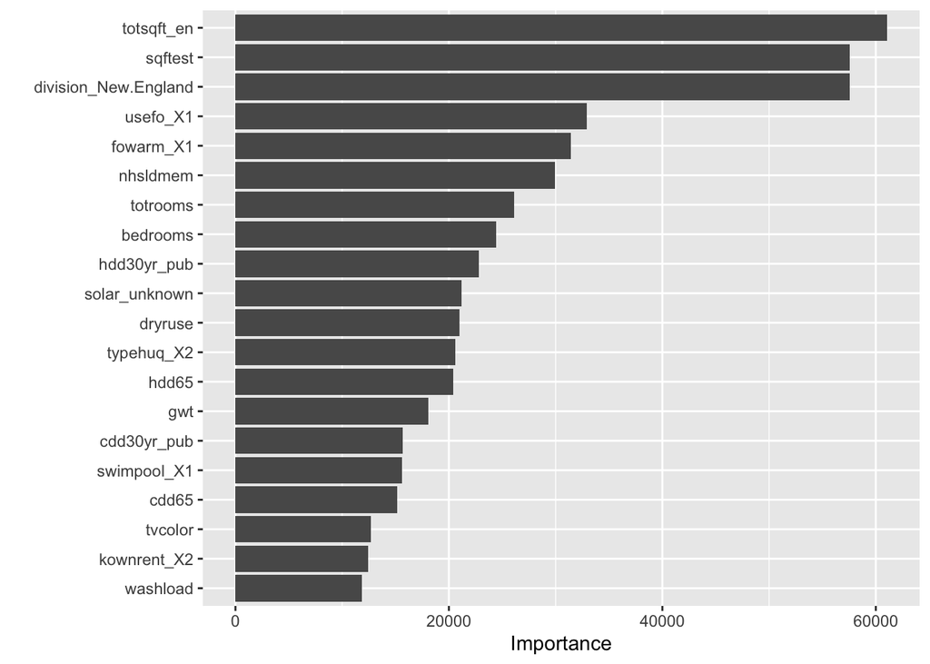

```r
vip(final_rf_fit$fit$fit, num_features = 20)
```

This variable importance plot highlights the top predictors of household energy costs, as identified by the permutation-based importance scores from the random forest model. Key drivers include home size (sqftest, totsqft_en), household size, and heating degree days—reinforcing the role of building characteristics and climate in shaping energy expenditures.

## Model 3: XGBoost

```r
xgb_rec <- recipe(cost ~ ., data = train_data) %>%
  update_role(doeid, new_role = "id") %>%
  step_unknown(all_nominal_predictors()) %>%
  step_dummy(all_nominal_predictors()) %>%
  step_impute_median(all_numeric_predictors()) %>%
  step_zv(all_predictors())

xgb_mod <- boost_tree(
  trees = 100,
  tree_depth = tune(),
  learn_rate = tune(),
  loss_reduction = tune(),
  sample_size = tune(),
  mtry = tune(),
  min_n = tune()
) %>%
  set_engine("xgboost") %>%
  set_mode("regression")

xgb_wf <- workflow() %>%
  add_recipe(xgb_rec) %>%
  add_model(xgb_mod)

xgb_grid <- grid_latin_hypercube(
  tree_depth(),
  learn_rate(),
  loss_reduction(),
  sample_size = sample_prop(),
  finalize(mtry(), train_data),
   min_n(),
  size = 20
)

set.seed(050525)

xgb_res <- tune_grid(
  xgb_wf,
  resamples = folds,
  grid = xgb_grid,
  metrics = metric_set(rmse, rsq),
  control = control_grid(verbose = TRUE)
)

xgb_res %>% show_best()
```

```
# A tibble: 5 × 12
   mtry min_n tree_depth learn_rate loss_reduction sample_size .metric
  <int> <int>      <int>      <dbl>          <dbl>       <dbl> <chr>
1   155    11         14   0.0274    0.000000593         0.915 rmse
2   143    24          7   0.0374    0.00000000390       0.153 rmse
3    33     5         14   0.00475   0.000000277         0.206 rmse
4    20    19         11   0.00255   0.102               0.368 rmse
5   108     2         10   0.000773  0.576               0.249 rmse
# ℹ 5 more variables: .estimator <chr>, mean <dbl>, n <int>, std_err <dbl>,
#   .config <chr>
```

```r
xgb_spec <- boost_tree(
  trees = 1000,
  tree_depth = 3,
  min_n = 38,
  loss_reduction = 0.0000003476791,
  sample_size = 0.7421415   ,
  mtry = 145,
  learn_rate = 0.089506014
) %>%
  set_engine("xgboost") %>%
  set_mode("regression")

xgb_wf <- workflow() %>%
  add_recipe(xgb_rec) %>%
  add_model(xgb_spec)

xgb_resamples <- fit_resamples(
  xgb_wf,
  resamples = folds,
  metrics = metric_set(rmse, rsq),
  control = control_resamples(save_pred = TRUE)
)
xgb_metrics <- collect_metrics(xgb_resamples)

final_xgb_fit <- fit(xgb_wf, data = train_data)

xgb_preds <- predict(final_xgb_fit, new_data = test_data) %>%
  bind_cols(test_data %>% select(cost))

metrics(xgb_preds, truth = cost, estimate = .pred)
```

```
# A tibble: 3 × 3
  .metric .estimator .estimate
  <chr>   <chr>          <dbl>
1 rmse    standard     706.
2 rsq     standard       0.585
3 mae     standard     483.
```

XGBoost shows the strongest predictive performance, suggesting the presence of non-linear and interaction effects that simpler models may fail to capture. However, Lasso remains valuable for interpretation and feature selection. These models can guide the targeting of energy subsidy programs by identifying households at higher risk of energy cost burden.

# Nonparametric Evaluation of Solar Panel Impact on Energy Costs

To complement our predictive modeling, we conduct a nonparametric analysis to estimate the causal effect of household solar panel installation on annual energy costs. Unlike traditional regression, this approach does not impose a functional form and better accommodates potential heterogeneity in household characteristics.

We begin by conducting a basic permutation test that compares the mean annual energy cost between households with and without solar panels. This test randomly shuffles the treatment label (solar) 1,000 times to generate a distribution of mean differences under the null hypothesis of no treatment effect.

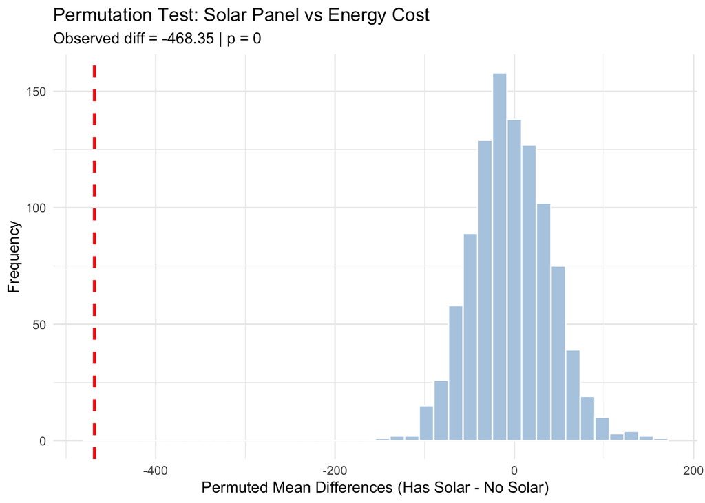

```r
recs_perm <- recs %>%
  filter(!is.na(solar), !is.na(cost)) %>%
  mutate(solar = factor(solar, labels = c("No Solar", "Has Solar")))


actual_diff <- recs_perm %>%
  group_by(solar) %>%
  summarise(mean_cost = mean(cost, na.rm = TRUE)) %>%
  summarise(diff = mean_cost[solar == "Has Solar"] - mean_cost[solar == "No Solar"]) %>%
  pull(diff)

set.seed(050525)
perm_diffs <- replicate(1000, {
  shuffled <- recs_perm %>%
    mutate(solar_perm = sample(solar)) %>%
    group_by(solar_perm) %>%
    summarise(mean_cost = mean(cost, na.rm = TRUE)) %>%
    summarise(diff = mean_cost[solar_perm == "Has Solar"] - mean_cost[solar_perm == "No Solar"]) %>%
    pull(diff)
})

p_value <- mean(abs(perm_diffs) >= abs(actual_diff))

view(p_value)


ggplot(data.frame(diff = perm_diffs), aes(x = diff)) +
  geom_histogram(bins = 40, fill = "#b3cde3", color = "white") +
  geom_vline(xintercept = actual_diff, color = "red", linetype = "dashed", linewidth = 1) +
  labs(
    title = "Permutation Test: Solar Panel vs Energy Cost",
    subtitle = paste("Observed diff =", round(actual_diff, 2), "| p =", round(p_value, 4)),
    x = "Permuted Mean Differences (Has Solar - No Solar)",
    y = "Frequency"
  ) +
  theme_minimal()
```

The permutation test shows a significant cost difference of $468 between households with and without solar panels (p = 0), suggesting a strong association. However, since solar adoption is not randomly assigned, this result may reflect confounding factors such as home size, age, or location rather than a causal effect.

## Matching-Based Permutation Test

To address this concern, we implement a Matching + Permutation Test. Using nearest neighbor matching based on income level (moneypy), square footage (sqftest), housing vintage (yearmaderange), and climate zone (ba_climate), we construct a sample of households with and without solar panels that are comparable on key characteristics.

This allows us to isolate the effect of solar panel installation while controlling for observed confounding variables.

```r
match_out <- matchit(solar ~ moneypy + sqftest + yearmaderange + ba_climate,
                     data = recs_perm,
                     method = "nearest", ratio = 1)

matched_data <- match.data(match_out)

actual_diff <- with(matched_data,
                    mean(cost[solar == "Has Solar"]) - mean(cost[solar == "No Solar"]))

set.seed(050525)
new_perm_diffs <- replicate(1000, {
  matched_data %>%
    mutate(solar_perm = sample(solar)) %>%
    group_by(solar_perm) %>%
    summarise(mean_cost = mean(cost, na.rm = TRUE)) %>%
    summarise(diff = mean_cost[solar_perm == "Has Solar"] - mean_cost[solar_perm == "No Solar"]) %>%
    pull(diff)
})

new_actual_diff <- matched_data %>%
  group_by(solar) %>%
  summarise(mean_cost = mean(cost, na.rm = TRUE)) %>%
  summarise(diff = mean_cost[solar == "Has Solar"] - mean_cost[solar == "No Solar"]) %>%
  pull(diff)


new_p_value <- (sum(abs(perm_diffs) >= abs(actual_diff)) + 1) / (length(perm_diffs) + 1)


view(new_p_value)
```

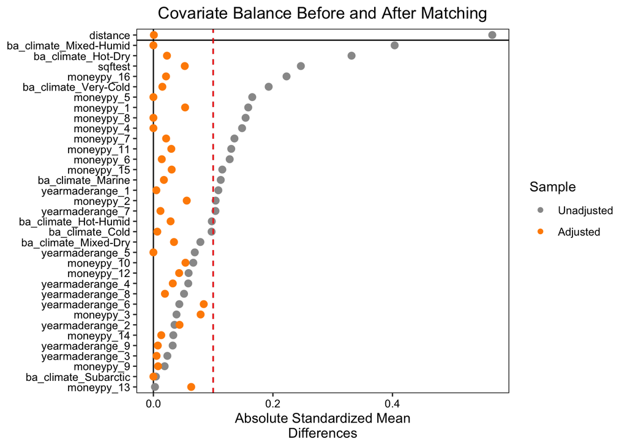

```r
love.plot(match_out,
          binary = "std",
          var.order = "unadjusted",
          threshold = 0.1,
          abs = TRUE,
          colors = c("gray60", "darkorange"),
          stat = "mean.diffs",
          title = "Covariate Balance Before and After Matching") +
  ggplot2::geom_vline(xintercept = 0.1, color = "red", linetype = "dashed")
```

The figure shows the standardized mean differences of covariates before and after matching. Gray dots represent covariate imbalance prior to matching, while orange dots indicate the balance achieved after matching. The matching procedure significantly improved covariate balance, with nearly all orange dots falling within the red dashed line threshold of 0.1. This suggests that households with and without solar panels are now highly comparable in terms of key characteristics such as income, square footage, year built, and climate zone.

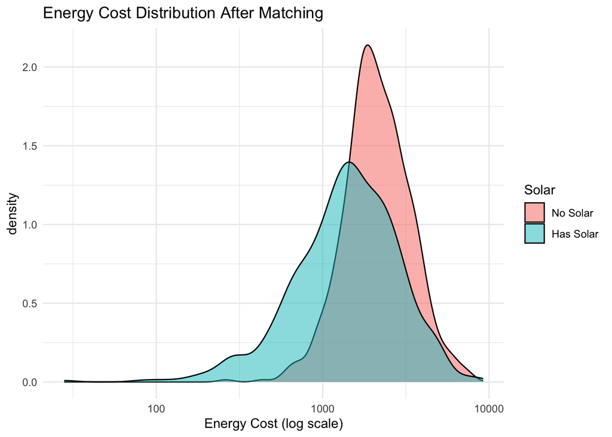

```r
matched_data %>%
  filter(!is.na(cost), cost > 0) %>%
  mutate(solar = factor(solar, labels = c("No Solar", "Has Solar"))) %>%
  ggplot(aes(x = cost, fill = solar)) +
  geom_density(alpha = 0.5) +
  scale_x_log10() +
  labs(title = "Energy Cost Distribution After Matching",
       x = "Energy Cost (log scale)", fill = "Solar") +
  theme_minimal()
```

The figure displays the density distribution of annual energy cost (in log scale) for matched households, separated by solar panel ownership. After matching on observable characteristics, households with solar panels still show a lower overall cost distribution. The shift of the blue curve (Has Solar) to the left confirms that solar adoption is associated with reduced energy costs even after accounting for structural differences.

## Further Discussion

### Determinants of Electricity Price

Our work aligns with broader findings in the literature on the **complex and interconnected nature of electricity pricing**. According to Girish et al. (2013), key price determinants in competitive electricity markets include demand fluctuations, generation fuel mix, and regulatory policy. [See study on ResearchGate](https://www.researchgate.net/publication/306200084_Determinants_of_Electricity_Price_in_Competitive_Power_Market#:~:text=A%20few%20factors%20that%20affect%20the%20price...).

This emphasizes that while **individual household characteristics** explain a portion of cost variation, **market-level factors** also play a critical role—highlighting the value of policy simulations to test what can be done within household-level control.

### The Case for Solar — and Its Limits

Our dataset shows that **solar panel adoption remains limited**, despite its association with reduced energy cost. This raises important questions: *Why isn’t solar more widespread?*

There are several possible reasons:

- As [Sunnova](https://www.sunnova.com/watts-up/how-do-solar-panels-work-with-your-electric-bill#:~:text=Yes%2C%20but%3A%20Your%20average%20monthly...) notes, solar panels **reduce but don’t eliminate** electric bills entirely, especially for homes that still rely on grid electricity during cloudy days or nights.
- According to [NerdWallet](https://www.nerdwallet.com/article/mortgages/solar-panels-electric-bill), the **upfront cost**, **loan options**, and **roof suitability** can limit solar adoption. The **return on investment** may take years, making it less appealing to lower-income homeowners or renters.

Thus, while solar is a promising solution, it must be paired with **supportive policies**—like incentives, subsidies, and community solar programs—to achieve widespread impact.